# Course porject: Practical Machine Learning on Qualitative Activity Recognition

Zhiyi Liu

9/2/2017

## Introduction

Personal movement devices such as Jawbone Up, Nike FuelBand, and Fitbit, are popular and can be used to collect a large amount of data about personal activity. In this project, we focus on qualifying self movement to automatically assessing movements in a particular dumbell lifting simulation. Recognizting particular movements and providing feedback on how well these movements are executed can significantly assist with automation of effective training.

In the simulation, six young health participants were asked to perform one set of 10 repetitions of the Unilateral Dumbbell Biceps Curl in five different fashions: exactly according to the specification (Class A), throwing the elbows to the front (Class B), lifting the dumbbell only halfway (Class C), lowering the dumbbell only halfway (Class D) and throwing the hips to the front (Class E). These are also the outcome variable (designated as ‘classe’ in the datasets) we want to predict in this analysis. The data were collected from accelerometers on the belt, forearm, arm, and dumbell. More information is available from the website here: http://web.archive.org/web/20161224072740/http:/groupware.les.inf.puc-rio.br/har

## Pre-processing of data

Set work directory and download the datasets

```r
setwd("/Users/zliu11/R_for_DScourses/Course8/CourseProject")
download.file("https://d396qusza40orc.cloudfront.net/predmachlearn/pml-training.csv", destfile = "pml-training.csv")
download.file("https://d396qusza40orc.cloudfront.net/predmachlearn/pml-testing.csv", destfile = "pml-testing.csv")
```

Read datasets, replacing all empty, “NA”, and “#DIV/0!” datapoints with “NA”

```r
library(data.table) # load the data.table library
setwd("/Users/zliu11/R_for_DScourses/Course8/CourseProject")
trainingDataset <- fread("/Users/zliu11/R_for_DScourses/Course8/CourseProject/pml-training.csv", na.strings = c("NA","",'#DIV/0!'), data.table = F)
testingDataset <- fread("/Users/zliu11/R_for_DScourses/Course8/CourseProject/pml-testing.csv", na.strings = c("NA","",'#DIV/0!'), data.table = F)
```

Clean the data, removing all columns (variables) containing “NA”.

We have noticed that in the dataset many columns contain NAs. These columns (variables) don’t contribute to the final model. Therefore we remove these variables.

```r
trainingDataset <- trainingDataset[,colSums(is.na(trainingDataset)) == 0]
trainingDataset <- trainingDataset[,8:length(names(trainingDataset))] # only keep relevant variables
testingDataset <- testingDataset[, colSums(is.na(testingDataset)) == 0]
testingDataset <- testingDataset[,8:length(names(testingDataset))] # only keep relevant variables
```

Split the trainingDataset into training and testing subsets.

We further split the trainingDataset into training and testing subsets for generating the fit models, as well as for conducting cross validation.

```r
library(ggplot2); library(caret)
set.seed(5839)
inTrain <- createDataPartition(y=trainingDataset$classe, p=0.6, list = F)
training <- trainingDataset[inTrain,]
testing <- trainingDataset[-inTrain,]
```

## Model Fitting

We first try the random forests method, followed by the boosting method. We will compare the two models and select the one having the better performance.

### 1. Random Forests

```r
set.seed(12324)
library(randomForest)
modRF <- train(classe ~ ., data = training, method = "rf", trControl=trainControl(method='cv'), number=5)
modRF$finalModel
```

```
##
## Call:
##  randomForest(x = x, y = y, mtry = param$mtry, number = 5)
##                Type of random forest: classification
##                      Number of trees: 500
## No. of variables tried at each split: 2
##
##         OOB estimate of  error rate: 0.93%
## Confusion matrix:
##      A    B    C    D    E class.error
## A 3342    5    1    0    0 0.001792115
## B   14 2257    8    0    0 0.009653357
## C    0   21 2029    4    0 0.012171373
## D    0    0   47 1882    1 0.024870466
## E    0    0    3    5 2157 0.003695150
```

```r
predRF <- predict(modRF, testing)
accuRF <- confusionMatrix(predRF, testing$classe) # calculate the accuracy
accuRF
```

```
## Confusion Matrix and Statistics
##
##           Reference
## Prediction    A    B    C    D    E
##          A 2231   16    0    0    0
##          B    0 1498   24    0    0
##          C    1    4 1341   31    3
##          D    0    0    3 1253    0
##          E    0    0    0    2 1439
##
## Overall Statistics
##
##                Accuracy : 0.9893
##                  95% CI : (0.9868, 0.9915)
##     No Information Rate : 0.2845
##     P-Value [Acc > NIR] : < 2.2e-16
##
##                   Kappa : 0.9865
##  Mcnemar's Test P-Value : NA
##
## Statistics by Class:
##
##                      Class: A Class: B Class: C Class: D Class: E
## Sensitivity            0.9996   0.9868   0.9803   0.9743   0.9979
## Specificity            0.9971   0.9962   0.9940   0.9995   0.9997
## Pos Pred Value         0.9929   0.9842   0.9717   0.9976   0.9986
## Neg Pred Value         0.9998   0.9968   0.9958   0.9950   0.9995
## Prevalence             0.2845   0.1935   0.1744   0.1639   0.1838
## Detection Rate         0.2843   0.1909   0.1709   0.1597   0.1834
## Detection Prevalence   0.2864   0.1940   0.1759   0.1601   0.1837
## Balanced Accuracy      0.9984   0.9915   0.9871   0.9869   0.9988
```

### 2. Boosting

```r
set.seed(2333)
library(gbm)
modGBM <- train(classe ~ ., data = training, method ="gbm")
modGBM$finalModel
```

[output not shown]

```r
predGBM <- predict(modGBM, testing)
accuGBM <- confusionMatrix(predGBM, testing$classe)
accuGBM
```

```
## Confusion Matrix and Statistics
##
##           Reference
## Prediction    A    B    C    D    E
##          A 2192   51    0    0    2
##          B   32 1423   50    3   14
##          C    6   43 1300   46   15
##          D    1    0   16 1230   24
##          E    1    1    2    7 1387
##
## Overall Statistics
##
##                Accuracy : 0.96
##                  95% CI : (0.9554, 0.9642)
##     No Information Rate : 0.2845
##     P-Value [Acc > NIR] : < 2.2e-16
##
##                   Kappa : 0.9494
##  Mcnemar's Test P-Value : 3.241e-09
##
## Statistics by Class:
##
##                      Class: A Class: B Class: C Class: D Class: E
## Sensitivity            0.9821   0.9374   0.9503   0.9565   0.9619
## Specificity            0.9906   0.9844   0.9830   0.9938   0.9983
## Pos Pred Value         0.9764   0.9350   0.9220   0.9677   0.9921
## Neg Pred Value         0.9929   0.9850   0.9894   0.9915   0.9915
## Prevalence             0.2845   0.1935   0.1744   0.1639   0.1838
## Detection Rate         0.2794   0.1814   0.1657   0.1568   0.1768
## Detection Prevalence   0.2861   0.1940   0.1797   0.1620   0.1782
## Balanced Accuracy      0.9863   0.9609   0.9667   0.9751   0.9801
```

Therefore, we see that the accuracy for modRF (random forests) is greater than that for modGBM (boosting). We choose the method of Random Forests for our final model fitting. To make it clear, let’s have a look at the significant contributing variables in `modRF`:

```r
varImp(modRF)
```

```
## rf variable importance
##
##   only 20 most important variables shown (out of 52)
##
##                      Overall
## roll_belt             100.00
## yaw_belt               80.94
## magnet_dumbbell_z      69.09
## magnet_dumbbell_y      61.75
## pitch_forearm          61.70
## pitch_belt             61.18
## magnet_dumbbell_x      52.61
## roll_forearm           49.87
## magnet_belt_y          46.02
## accel_belt_z           44.90
## accel_dumbbell_y       44.25
## roll_dumbbell          44.18
## magnet_belt_z          43.35
## accel_dumbbell_z       37.38
## roll_arm               35.07
## accel_forearm_x        34.00
## gyros_belt_z           30.27
## accel_dumbbell_x       29.73
## magnet_arm_x           28.32
## total_accel_dumbbell   28.26
```

A plot will demonstrate the above point:

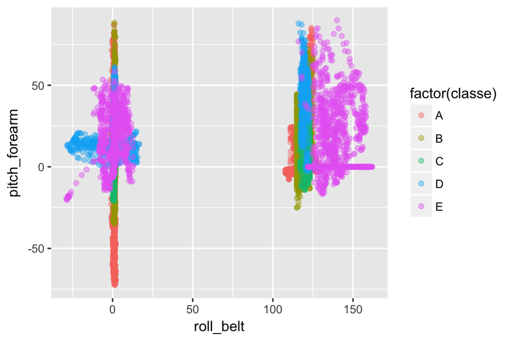

```r
library(ggplot2)
p <- ggplot(data = training, aes(x=roll_belt, y=pitch_forearm, color = factor(classe))) +
        geom_point(alpha=0.4)
p
```

## Model validation

We use the `testingDataset` to validate the Random Forests model, `modRF`, and get the predictions for the questions asked by the assignment:

```r
predValidate <- predict(modRF, testingDataset)
predValidate
```

```
##  [1] B A B A A E D B A A B C B A E E A B B B
## Levels: A B C D E
```